# Project: Investigate Soccer Dataset

- Introduction
- Data Wrangling
- Exploratory Data Analysis
- Conclusions
- Communication

## Introduction

The Soccer dataset consists mainly of three main data groups:

1. Data about home and away teams' scored goals and betting odds data for +25,000 matches
2. Data about players' names, birthday, height and weight with attributes sourced from EA Sports' FIFA video game series
3. Data about teams' long and short names with attributes also sourced from FIFA, including the weekly updates

We will load these data sources in the next section from SQLite database and group them as mentioned above.

```python
# import needed packages
import pandas as pd
import numpy as np
from sqlalchemy import create_engine
```

```python
# Create SQLAlchemy Engine to connect to Soccer sqlite database
engine = create_engine('sqlite:///database.sqlite')
```

### Read database data into a pandas DataFrame

Load each table from the database into a separate pandas DataFrame.

```python
# Load Country table from database
df_country = pd.read_sql('SELECT * FROM Country', engine)

# Display Country dataframe
df_country
```

|  | id | name |
| --- | --- | --- |
| 0 | 1 | Belgium |
| 1 | 1729 | England |
| 2 | 4769 | France |
| 3 | 7809 | Germany |
| 4 | 10257 | Italy |
| 5 | 13274 | Netherlands |
| 6 | 15722 | Poland |
| 7 | 17642 | Portugal |
| 8 | 19694 | Scotland |
| 9 | 21518 | Spain |
| 10 | 24558 | Switzerland |

```python
# Load League table from database
df_league = pd.read_sql('SELECT * FROM League', engine)

# Display League dataframe
df_league
```

|  | id | country_id | name |
| --- | --- | --- | --- |
| 0 | 1 | 1 | Belgium Jupiler League |
| 1 | 1729 | 1729 | England Premier League |
| 2 | 4769 | 4769 | France Ligue 1 |
| 3 | 7809 | 7809 | Germany 1. Bundesliga |
| 4 | 10257 | 10257 | Italy Serie A |
| 5 | 13274 | 13274 | Netherlands Eredivisie |
| 6 | 15722 | 15722 | Poland Ekstraklasa |
| 7 | 17642 | 17642 | Portugal Liga ZON Sagres |
| 8 | 19694 | 19694 | Scotland Premier League |
| 9 | 21518 | 21518 | Spain LIGA BBVA |
| 10 | 24558 | 24558 | Switzerland Super League |

```python
# Load Match table from database
df_match = pd.read_sql('SELECT * FROM Match', engine)

# Display first 5 rows from Match dataframe
df_match.head()
```

|  | id | country_id | league_id | season | stage | date | match_api_id | home_team_api_id | away_team_api_id | home_team_goal | ... | SJA | VCH | VCD | VCA | GBH | GBD | GBA | BSH | BSD | BSA |
| --- | --- | --- | --- | --- | --- | --- | --- | --- | --- | --- | --- | --- | --- | --- | --- | --- | --- | --- | --- | --- | --- |
| 0 | 1 | 1 | 1 | 2008/2009 | 1 | 2008-08-17 00:00:00 | 492473 | 9987 | 9993 | 1 | ... | 4.00 | 1.65 | 3.40 | 4.50 | 1.78 | 3.25 | 4.00 | 1.73 | 3.40 | 4.20 |
| 1 | 2 | 1 | 1 | 2008/2009 | 1 | 2008-08-16 00:00:00 | 492474 | 10000 | 9994 | 0 | ... | 3.80 | 2.00 | 3.25 | 3.25 | 1.85 | 3.25 | 3.75 | 1.91 | 3.25 | 3.60 |
| 2 | 3 | 1 | 1 | 2008/2009 | 1 | 2008-08-16 00:00:00 | 492475 | 9984 | 8635 | 0 | ... | 2.50 | 2.35 | 3.25 | 2.65 | 2.50 | 3.20 | 2.50 | 2.30 | 3.20 | 2.75 |
| 3 | 4 | 1 | 1 | 2008/2009 | 1 | 2008-08-17 00:00:00 | 492476 | 9991 | 9998 | 5 | ... | 7.50 | 1.45 | 3.75 | 6.50 | 1.50 | 3.75 | 5.50 | 1.44 | 3.75 | 6.50 |
| 4 | 5 | 1 | 1 | 2008/2009 | 1 | 2008-08-16 00:00:00 | 492477 | 7947 | 9985 | 1 | ... | 1.73 | 4.50 | 3.40 | 1.65 | 4.50 | 3.50 | 1.65 | 4.75 | 3.30 | 1.67 |

5 rows × 115 columns

```python
# Load Player table from database
df_player = pd.read_sql('SELECT * FROM Player', engine)

# Display first 5 rows from Player dataframe
df_player.head()
```

|  | id | player_api_id | player_name | player_fifa_api_id | birthday | height | weight |
| --- | --- | --- | --- | --- | --- | --- | --- |
| 0 | 1 | 505942 | Aaron Appindangoye | 218353 | 1992-02-29 00:00:00 | 182.88 | 187 |
| 1 | 2 | 155782 | Aaron Cresswell | 189615 | 1989-12-15 00:00:00 | 170.18 | 146 |
| 2 | 3 | 162549 | Aaron Doran | 186170 | 1991-05-13 00:00:00 | 170.18 | 163 |
| 3 | 4 | 30572 | Aaron Galindo | 140161 | 1982-05-08 00:00:00 | 182.88 | 198 |
| 4 | 5 | 23780 | Aaron Hughes | 17725 | 1979-11-08 00:00:00 | 182.88 | 154 |

```python
# Load Player_Attributes table from database
df_player_attributes = pd.read_sql('SELECT * FROM Player_Attributes', engine)

# Display first 5 rows from Player_Attributes dataframe
df_player_attributes.head()
```

|  | id | player_fifa_api_id | player_api_id | date | overall_rating | potential | preferred_foot | attacking_work_rate | defensive_work_rate | crossing | ... | vision | penalties | marking | standing_tackle | sliding_tackle | gk_diving | gk_handling | gk_kicking | gk_positioning | gk_reflexes |
| --- | --- | --- | --- | --- | --- | --- | --- | --- | --- | --- | --- | --- | --- | --- | --- | --- | --- | --- | --- | --- | --- |
| 0 | 1 | 218353 | 505942 | 2016-02-18 00:00:00 | 67.0 | 71.0 | right | medium | medium | 49.0 | ... | 54.0 | 48.0 | 65.0 | 69.0 | 69.0 | 6.0 | 11.0 | 10.0 | 8.0 | 8.0 |
| 1 | 2 | 218353 | 505942 | 2015-11-19 00:00:00 | 67.0 | 71.0 | right | medium | medium | 49.0 | ... | 54.0 | 48.0 | 65.0 | 69.0 | 69.0 | 6.0 | 11.0 | 10.0 | 8.0 | 8.0 |
| 2 | 3 | 218353 | 505942 | 2015-09-21 00:00:00 | 62.0 | 66.0 | right | medium | medium | 49.0 | ... | 54.0 | 48.0 | 65.0 | 66.0 | 69.0 | 6.0 | 11.0 | 10.0 | 8.0 | 8.0 |
| 3 | 4 | 218353 | 505942 | 2015-03-20 00:00:00 | 61.0 | 65.0 | right | medium | medium | 48.0 | ... | 53.0 | 47.0 | 62.0 | 63.0 | 66.0 | 5.0 | 10.0 | 9.0 | 7.0 | 7.0 |
| 4 | 5 | 218353 | 505942 | 2007-02-22 00:00:00 | 61.0 | 65.0 | right | medium | medium | 48.0 | ... | 53.0 | 47.0 | 62.0 | 63.0 | 66.0 | 5.0 | 10.0 | 9.0 | 7.0 | 7.0 |

5 rows × 42 columns

```python
# Load Team table from database
df_team = pd.read_sql('SELECT * FROM Team', engine)

# Display first 5 rows from Team dataframe
df_team.head()
```

|  | id | team_api_id | team_fifa_api_id | team_long_name | team_short_name |
| --- | --- | --- | --- | --- | --- |
| 0 | 1 | 9987 | 673.0 | KRC Genk | GEN |
| 1 | 2 | 9993 | 675.0 | Beerschot AC | BAC |
| 2 | 3 | 10000 | 15005.0 | SV Zulte-Waregem | ZUL |
| 3 | 4 | 9994 | 2007.0 | Sporting Lokeren | LOK |
| 4 | 5 | 9984 | 1750.0 | KSV Cercle Brugge | CEB |

```python
# Load Team_Attributes table from database
df_team_attributes = pd.read_sql('SELECT * FROM Team_Attributes', engine)

# Display first 5 rows from Team_Attributes dataframe
df_team_attributes.head()
```

|  | id | team_fifa_api_id | team_api_id | date | buildUpPlaySpeed | buildUpPlaySpeedClass | buildUpPlayDribbling | buildUpPlayDribblingClass | buildUpPlayPassing | buildUpPlayPassingClass | ... | chanceCreationShooting | chanceCreationShootingClass | chanceCreationPositioningClass | defencePressure | defencePressureClass | defenceAggression | defenceAggressionClass | defenceTeamWidth | defenceTeamWidthClass | defenceDefenderLineClass |
| --- | --- | --- | --- | --- | --- | --- | --- | --- | --- | --- | --- | --- | --- | --- | --- | --- | --- | --- | --- | --- | --- |
| 0 | 1 | 434 | 9930 | 2010-02-22 00:00:00 | 60 | Balanced | NaN | Little | 50 | Mixed | ... | 55 | Normal | Organised | 50 | Medium | 55 | Press | 45 | Normal | Cover |
| 1 | 2 | 434 | 9930 | 2014-09-19 00:00:00 | 52 | Balanced | 48.0 | Normal | 56 | Mixed | ... | 64 | Normal | Organised | 47 | Medium | 44 | Press | 54 | Normal | Cover |
| 2 | 3 | 434 | 9930 | 2015-09-10 00:00:00 | 47 | Balanced | 41.0 | Normal | 54 | Mixed | ... | 64 | Normal | Organised | 47 | Medium | 44 | Press | 54 | Normal | Cover |
| 3 | 4 | 77 | 8485 | 2010-02-22 00:00:00 | 70 | Fast | NaN | Little | 70 | Long | ... | 70 | Lots | Organised | 60 | Medium | 70 | Double | 70 | Wide | Cover |
| 4 | 5 | 77 | 8485 | 2011-02-22 00:00:00 | 47 | Balanced | NaN | Little | 52 | Mixed | ... | 52 | Normal | Organised | 47 | Medium | 47 | Press | 52 | Normal | Cover |

5 rows × 25 columns

### Join tables to create the 3 main DataFrame groups

Next we will create the **1st group** for Matches' data by joining **Country** and **League** tables to **Match** table then dropping uneeded columns.

```python
# Left join Country dataframe to League dataframe by id column
# Suffix is used to differentiate "name" column from both dataframes
df_country_league = df_country.set_index('id').join(df_league.set_index('id'), lsuffix='_country', rsuffix='_league')

# Display first 5 rows from joined Country and League dataframes
df_country_league.head()
```

| id | name_country | country_id | name_league |
| --- | --- | --- | --- |
| 1 | Belgium | 1 | Belgium Jupiler League |
| 1729 | England | 1729 | England Premier League |
| 4769 | France | 4769 | France Ligue 1 |
| 7809 | Germany | 7809 | Germany 1. Bundesliga |
| 10257 | Italy | 10257 | Italy Serie A |

Now we need to remove uneeded columns from **Match** table. Since we are not interested the betting odds data and since a big portion of the `player_X` data is `NULL`, so we can drop their corresponding columns to make **Match** data easier for analysis.

Next we will display the corresponding indicies for all columns in **Match** dataframe.

```python
# View the index number and label for each column
for i, v in enumerate(df_match.columns):
    print(i, v)
```

```
0 id
1 country_id
2 league_id
3 season
4 stage
5 date
6 match_api_id
7 home_team_api_id
8 away_team_api_id
9 home_team_goal
10 away_team_goal
11 home_player_X1
12 home_player_X2
13 home_player_X3
14 home_player_X4
```

[output cut: 100 more lines]

We can see that the uneeded columns start from `index` **11**. So, we can drop starting from there to the end.

```python
# Drop uneeded Player_X and Betting Odds data columns
df_match.drop(df_match.iloc[:, 11:], inplace = True, axis = 1)

# Display dataframe to check after dropping
df_match.head()
```

|  | id | country_id | league_id | season | stage | date | match_api_id | home_team_api_id | away_team_api_id | home_team_goal | away_team_goal |
| --- | --- | --- | --- | --- | --- | --- | --- | --- | --- | --- | --- |
| 0 | 1 | 1 | 1 | 2008/2009 | 1 | 2008-08-17 00:00:00 | 492473 | 9987 | 9993 | 1 | 1 |
| 1 | 2 | 1 | 1 | 2008/2009 | 1 | 2008-08-16 00:00:00 | 492474 | 10000 | 9994 | 0 | 0 |
| 2 | 3 | 1 | 1 | 2008/2009 | 1 | 2008-08-16 00:00:00 | 492475 | 9984 | 8635 | 0 | 3 |
| 3 | 4 | 1 | 1 | 2008/2009 | 1 | 2008-08-17 00:00:00 | 492476 | 9991 | 9998 | 5 | 0 |
| 4 | 5 | 1 | 1 | 2008/2009 | 1 | 2008-08-16 00:00:00 | 492477 | 7947 | 9985 | 1 | 3 |

Now we can join **Match** table to the already joined **Country** and **League** tables.

```python
# Left join Match dataframe to pre-joined Country and League dataframes by country_id column
df_match = df_match.set_index('id').join(df_country_league.set_index('country_id'), on='country_id')
```

We can now drop the no longer needed id columns after joining tables.

```python
# Drop uneeded country_id, league_id and match_api_id columns
df_match.drop(['country_id', 'league_id', 'match_api_id'], axis = 1, inplace = True)

# Display dataframe to check after dropping
df_match.head()
```

| id | season | stage | date | home_team_api_id | away_team_api_id | home_team_goal | away_team_goal | name_country | name_league |
| --- | --- | --- | --- | --- | --- | --- | --- | --- | --- |
| 1 | 2008/2009 | 1 | 2008-08-17 00:00:00 | 9987 | 9993 | 1 | 1 | Belgium | Belgium Jupiler League |
| 2 | 2008/2009 | 1 | 2008-08-16 00:00:00 | 10000 | 9994 | 0 | 0 | Belgium | Belgium Jupiler League |
| 3 | 2008/2009 | 1 | 2008-08-16 00:00:00 | 9984 | 8635 | 0 | 3 | Belgium | Belgium Jupiler League |
| 4 | 2008/2009 | 1 | 2008-08-17 00:00:00 | 9991 | 9998 | 5 | 0 | Belgium | Belgium Jupiler League |
| 5 | 2008/2009 | 1 | 2008-08-16 00:00:00 | 7947 | 9985 | 1 | 3 | Belgium | Belgium Jupiler League |

Next we will create the **2nd group** for Players' data by joining **Player** and **Player_Attributes** tables then dropping uneeded columns.

```python
# Drop uneeded id and player_fifa_api_id columns from Player dataframe
df_player.drop(['id', 'player_fifa_api_id'], axis = 1, inplace = True)

# Display dataframe to check after dropping
df_player.head()
```

|  | player_api_id | player_name | birthday | height | weight |
| --- | --- | --- | --- | --- | --- |
| 0 | 505942 | Aaron Appindangoye | 1992-02-29 00:00:00 | 182.88 | 187 |
| 1 | 155782 | Aaron Cresswell | 1989-12-15 00:00:00 | 170.18 | 146 |
| 2 | 162549 | Aaron Doran | 1991-05-13 00:00:00 | 170.18 | 163 |
| 3 | 30572 | Aaron Galindo | 1982-05-08 00:00:00 | 182.88 | 198 |
| 4 | 23780 | Aaron Hughes | 1979-11-08 00:00:00 | 182.88 | 154 |

```python
# Left join Player_attributes dataframe to Player dataframe by player_api_id column
df_player_attributes = df_player_attributes.set_index('id').join(df_player.set_index('player_api_id'), on='player_api_id')

# Display dataframe to check after joining
df_player_attributes.head()
```

| id | player_fifa_api_id | player_api_id | date | overall_rating | potential | preferred_foot | attacking_work_rate | defensive_work_rate | crossing | finishing | ... | sliding_tackle | gk_diving | gk_handling | gk_kicking | gk_positioning | gk_reflexes | player_name | birthday | height | weight |
| --- | --- | --- | --- | --- | --- | --- | --- | --- | --- | --- | --- | --- | --- | --- | --- | --- | --- | --- | --- | --- | --- |
| 1 | 218353 | 505942 | 2016-02-18 00:00:00 | 67.0 | 71.0 | right | medium | medium | 49.0 | 44.0 | ... | 69.0 | 6.0 | 11.0 | 10.0 | 8.0 | 8.0 | Aaron Appindangoye | 1992-02-29 00:00:00 | 182.88 | 187 |
| 2 | 218353 | 505942 | 2015-11-19 00:00:00 | 67.0 | 71.0 | right | medium | medium | 49.0 | 44.0 | ... | 69.0 | 6.0 | 11.0 | 10.0 | 8.0 | 8.0 | Aaron Appindangoye | 1992-02-29 00:00:00 | 182.88 | 187 |
| 3 | 218353 | 505942 | 2015-09-21 00:00:00 | 62.0 | 66.0 | right | medium | medium | 49.0 | 44.0 | ... | 69.0 | 6.0 | 11.0 | 10.0 | 8.0 | 8.0 | Aaron Appindangoye | 1992-02-29 00:00:00 | 182.88 | 187 |
| 4 | 218353 | 505942 | 2015-03-20 00:00:00 | 61.0 | 65.0 | right | medium | medium | 48.0 | 43.0 | ... | 66.0 | 5.0 | 10.0 | 9.0 | 7.0 | 7.0 | Aaron Appindangoye | 1992-02-29 00:00:00 | 182.88 | 187 |
| 5 | 218353 | 505942 | 2007-02-22 00:00:00 | 61.0 | 65.0 | right | medium | medium | 48.0 | 43.0 | ... | 66.0 | 5.0 | 10.0 | 9.0 | 7.0 | 7.0 | Aaron Appindangoye | 1992-02-29 00:00:00 | 182.88 | 187 |

5 rows × 45 columns

```python
# Drop uneeded player_fifa_api_id and player_api_id columns from Player_Attributes dataframe
df_player_attributes.drop(['player_fifa_api_id', 'player_api_id'], axis = 1, inplace = True)

# Display dataframe to check after dropping
df_player_attributes.head()
```

| id | date | overall_rating | potential | preferred_foot | attacking_work_rate | defensive_work_rate | crossing | finishing | heading_accuracy | short_passing | ... | sliding_tackle | gk_diving | gk_handling | gk_kicking | gk_positioning | gk_reflexes | player_name | birthday | height | weight |
| --- | --- | --- | --- | --- | --- | --- | --- | --- | --- | --- | --- | --- | --- | --- | --- | --- | --- | --- | --- | --- | --- |
| 1 | 2016-02-18 00:00:00 | 67.0 | 71.0 | right | medium | medium | 49.0 | 44.0 | 71.0 | 61.0 | ... | 69.0 | 6.0 | 11.0 | 10.0 | 8.0 | 8.0 | Aaron Appindangoye | 1992-02-29 00:00:00 | 182.88 | 187 |
| 2 | 2015-11-19 00:00:00 | 67.0 | 71.0 | right | medium | medium | 49.0 | 44.0 | 71.0 | 61.0 | ... | 69.0 | 6.0 | 11.0 | 10.0 | 8.0 | 8.0 | Aaron Appindangoye | 1992-02-29 00:00:00 | 182.88 | 187 |
| 3 | 2015-09-21 00:00:00 | 62.0 | 66.0 | right | medium | medium | 49.0 | 44.0 | 71.0 | 61.0 | ... | 69.0 | 6.0 | 11.0 | 10.0 | 8.0 | 8.0 | Aaron Appindangoye | 1992-02-29 00:00:00 | 182.88 | 187 |
| 4 | 2015-03-20 00:00:00 | 61.0 | 65.0 | right | medium | medium | 48.0 | 43.0 | 70.0 | 60.0 | ... | 66.0 | 5.0 | 10.0 | 9.0 | 7.0 | 7.0 | Aaron Appindangoye | 1992-02-29 00:00:00 | 182.88 | 187 |
| 5 | 2007-02-22 00:00:00 | 61.0 | 65.0 | right | medium | medium | 48.0 | 43.0 | 70.0 | 60.0 | ... | 66.0 | 5.0 | 10.0 | 9.0 | 7.0 | 7.0 | Aaron Appindangoye | 1992-02-29 00:00:00 | 182.88 | 187 |

5 rows × 43 columns

Next we will create the **3rd group** for Teams' data by joining **Team** and **Team_Attributes** tables then dropping uneeded columns.

```python
# Drop uneeded id and team_fifa_api_id columns from Team dataframe
df_team.drop(['id', 'team_fifa_api_id'], axis = 1, inplace = True)

# Display dataframe to check after dropping
df_team.head()
```

|  | team_api_id | team_long_name | team_short_name |
| --- | --- | --- | --- |
| 0 | 9987 | KRC Genk | GEN |
| 1 | 9993 | Beerschot AC | BAC |
| 2 | 10000 | SV Zulte-Waregem | ZUL |
| 3 | 9994 | Sporting Lokeren | LOK |
| 4 | 9984 | KSV Cercle Brugge | CEB |

```python
# Left join Team_attributes dataframe to Team dataframe by team_api_id column
df_team_attributes = df_team_attributes.set_index('id').join(df_team.set_index('team_api_id'), on='team_api_id')

# Display dataframe to check after joining
df_team_attributes.head()
```

| id | team_fifa_api_id | team_api_id | date | buildUpPlaySpeed | buildUpPlaySpeedClass | buildUpPlayDribbling | buildUpPlayDribblingClass | buildUpPlayPassing | buildUpPlayPassingClass | buildUpPlayPositioningClass | ... | chanceCreationPositioningClass | defencePressure | defencePressureClass | defenceAggression | defenceAggressionClass | defenceTeamWidth | defenceTeamWidthClass | defenceDefenderLineClass | team_long_name | team_short_name |
| --- | --- | --- | --- | --- | --- | --- | --- | --- | --- | --- | --- | --- | --- | --- | --- | --- | --- | --- | --- | --- | --- |
| 1 | 434 | 9930 | 2010-02-22 00:00:00 | 60 | Balanced | NaN | Little | 50 | Mixed | Organised | ... | Organised | 50 | Medium | 55 | Press | 45 | Normal | Cover | FC Aarau | AAR |
| 2 | 434 | 9930 | 2014-09-19 00:00:00 | 52 | Balanced | 48.0 | Normal | 56 | Mixed | Organised | ... | Organised | 47 | Medium | 44 | Press | 54 | Normal | Cover | FC Aarau | AAR |
| 3 | 434 | 9930 | 2015-09-10 00:00:00 | 47 | Balanced | 41.0 | Normal | 54 | Mixed | Organised | ... | Organised | 47 | Medium | 44 | Press | 54 | Normal | Cover | FC Aarau | AAR |
| 4 | 77 | 8485 | 2010-02-22 00:00:00 | 70 | Fast | NaN | Little | 70 | Long | Organised | ... | Organised | 60 | Medium | 70 | Double | 70 | Wide | Cover | Aberdeen | ABE |
| 5 | 77 | 8485 | 2011-02-22 00:00:00 | 47 | Balanced | NaN | Little | 52 | Mixed | Organised | ... | Organised | 47 | Medium | 47 | Press | 52 | Normal | Cover | Aberdeen | ABE |

5 rows × 26 columns

```python
# Drop uneeded team_fifa_api_id and team_api_id columns from Team_Attributes dataframe
df_team_attributes.drop(['team_fifa_api_id', 'team_api_id'], axis = 1, inplace = True)

# Display dataframe to check after dropping
df_team_attributes.head()
```

| id | date | buildUpPlaySpeed | buildUpPlaySpeedClass | buildUpPlayDribbling | buildUpPlayDribblingClass | buildUpPlayPassing | buildUpPlayPassingClass | buildUpPlayPositioningClass | chanceCreationPassing | chanceCreationPassingClass | ... | chanceCreationPositioningClass | defencePressure | defencePressureClass | defenceAggression | defenceAggressionClass | defenceTeamWidth | defenceTeamWidthClass | defenceDefenderLineClass | team_long_name | team_short_name |
| --- | --- | --- | --- | --- | --- | --- | --- | --- | --- | --- | --- | --- | --- | --- | --- | --- | --- | --- | --- | --- | --- |
| 1 | 2010-02-22 00:00:00 | 60 | Balanced | NaN | Little | 50 | Mixed | Organised | 60 | Normal | ... | Organised | 50 | Medium | 55 | Press | 45 | Normal | Cover | FC Aarau | AAR |
| 2 | 2014-09-19 00:00:00 | 52 | Balanced | 48.0 | Normal | 56 | Mixed | Organised | 54 | Normal | ... | Organised | 47 | Medium | 44 | Press | 54 | Normal | Cover | FC Aarau | AAR |
| 3 | 2015-09-10 00:00:00 | 47 | Balanced | 41.0 | Normal | 54 | Mixed | Organised | 54 | Normal | ... | Organised | 47 | Medium | 44 | Press | 54 | Normal | Cover | FC Aarau | AAR |
| 4 | 2010-02-22 00:00:00 | 70 | Fast | NaN | Little | 70 | Long | Organised | 70 | Risky | ... | Organised | 60 | Medium | 70 | Double | 70 | Wide | Cover | Aberdeen | ABE |
| 5 | 2011-02-22 00:00:00 | 47 | Balanced | NaN | Little | 52 | Mixed | Organised | 53 | Normal | ... | Organised | 47 | Medium | 47 | Press | 52 | Normal | Cover | Aberdeen | ABE |

5 rows × 24 columns

We can also use **home** and **away** teams' names instead of `api_ids` in **Match** table by joining **Team** table to it as follows.

```python
# Left join Match dataframe to Team dataframe by team_api_id and home_team_api_id columns
df_match = df_match.join(df_team.set_index('team_api_id'), on='home_team_api_id')
# Left join Match dataframe to Team dataframe by team_api_id and away_team_api_id columns
# Suffix is used to differentiate home and away teams' names
df_match = df_match.join(df_team.set_index('team_api_id'), on='away_team_api_id', lsuffix='_home', rsuffix='_away')

# Display dataframe to check after joining
df_match.head()
```

| id | season | stage | date | home_team_api_id | away_team_api_id | home_team_goal | away_team_goal | name_country | name_league | team_long_name_home | team_short_name_home | team_long_name_away | team_short_name_away |
| --- | --- | --- | --- | --- | --- | --- | --- | --- | --- | --- | --- | --- | --- |
| 1 | 2008/2009 | 1 | 2008-08-17 00:00:00 | 9987 | 9993 | 1 | 1 | Belgium | Belgium Jupiler League | KRC Genk | GEN | Beerschot AC | BAC |
| 2 | 2008/2009 | 1 | 2008-08-16 00:00:00 | 10000 | 9994 | 0 | 0 | Belgium | Belgium Jupiler League | SV Zulte-Waregem | ZUL | Sporting Lokeren | LOK |
| 3 | 2008/2009 | 1 | 2008-08-16 00:00:00 | 9984 | 8635 | 0 | 3 | Belgium | Belgium Jupiler League | KSV Cercle Brugge | CEB | RSC Anderlecht | AND |
| 4 | 2008/2009 | 1 | 2008-08-17 00:00:00 | 9991 | 9998 | 5 | 0 | Belgium | Belgium Jupiler League | KAA Gent | GEN | RAEC Mons | MON |
| 5 | 2008/2009 | 1 | 2008-08-16 00:00:00 | 7947 | 9985 | 1 | 3 | Belgium | Belgium Jupiler League | FCV Dender EH | DEN | Standard de Liège | STL |

```python
# Drop uneeded home_team_api_id and away_team_api_id columns from Match dataframe
df_match.drop(['home_team_api_id', 'away_team_api_id'], axis = 1, inplace = True)

# Display dataframe to check after dropping
df_match.head()
```

| id | season | stage | date | home_team_goal | away_team_goal | name_country | name_league | team_long_name_home | team_short_name_home | team_long_name_away | team_short_name_away |
| --- | --- | --- | --- | --- | --- | --- | --- | --- | --- | --- | --- |
| 1 | 2008/2009 | 1 | 2008-08-17 00:00:00 | 1 | 1 | Belgium | Belgium Jupiler League | KRC Genk | GEN | Beerschot AC | BAC |
| 2 | 2008/2009 | 1 | 2008-08-16 00:00:00 | 0 | 0 | Belgium | Belgium Jupiler League | SV Zulte-Waregem | ZUL | Sporting Lokeren | LOK |
| 3 | 2008/2009 | 1 | 2008-08-16 00:00:00 | 0 | 3 | Belgium | Belgium Jupiler League | KSV Cercle Brugge | CEB | RSC Anderlecht | AND |
| 4 | 2008/2009 | 1 | 2008-08-17 00:00:00 | 5 | 0 | Belgium | Belgium Jupiler League | KAA Gent | GEN | RAEC Mons | MON |
| 5 | 2008/2009 | 1 | 2008-08-16 00:00:00 | 1 | 3 | Belgium | Belgium Jupiler League | FCV Dender EH | DEN | Standard de Liège | STL |

Now we have created the three main data groups which we can use to help us answer the following questions:

- Which players had the highest penalties' ratings of all time?
- What team's attributes lead to the most victories?
- What teams improved the most over the time period?

## Data Wrangling

Next we will assess and inspect each data group and clean missing and duplicated data.

### General Properties of 1st Group

We will assess the properties of **Matches** data group and check if any cleaning steps is needed.

```python
# Check dimensions of Match table
df_match.shape
```

```
(25979, 11)
```

```python
# Check data types for each column and which
# columns have missing values with info()
df_match.info()
```

```
<class 'pandas.core.frame.DataFrame'>
Int64Index: 25979 entries, 1 to 25979
Data columns (total 11 columns):
 #   Column                Non-Null Count  Dtype
---  ------                --------------  -----
 0   season                25979 non-null  object
 1   stage                 25979 non-null  int64
 2   date                  25979 non-null  object
 3   home_team_goal        25979 non-null  int64
 4   away_team_goal        25979 non-null  int64
 5   name_country          25979 non-null  object
 6   name_league           25979 non-null  object
 7   team_long_name_home   25979 non-null  object
 8   team_short_name_home  25979 non-null  object
 9   team_long_name_away   25979 non-null  object
 10  team_short_name_away  25979 non-null  object
dtypes: int64(3), object(8)
memory usage: 2.4+ MB
```

No `null` columns or missing data in the **Match** dataframe.

```python
# check number of unique values in each column
df_match.nunique()
```

```
season                     8
stage                     38
date                    1694
home_team_goal            11
away_team_goal            10
name_country              11
name_league               11
team_long_name_home      296
team_short_name_home     259
team_long_name_away      296
team_short_name_away     259
dtype: int64
```

```python
# Display useful descriptive statistics for each column of data
df_match.describe()
```

|  | stage | home_team_goal | away_team_goal |
| --- | --- | --- | --- |
| count | 25979.000000 | 25979.000000 | 25979.000000 |
| mean | 18.242773 | 1.544594 | 1.160938 |
| std | 10.407354 | 1.297158 | 1.142110 |
| min | 1.000000 | 0.000000 | 0.000000 |
| 25% | 9.000000 | 1.000000 | 0.000000 |
| 50% | 18.000000 | 1.000000 | 1.000000 |
| 75% | 27.000000 | 2.000000 | 2.000000 |
| max | 38.000000 | 10.000000 | 9.000000 |

```python
# Check for duplicates in the data
sum(df_match.duplicated())
```

```
0
```

No duplicates records found in the **Match** dataframe.

> It seems that the **Matches** data group is already clean and ready for analysis usage!

### General Properties of 2nd Group

We will assess the properties of **Players** data group and check if any cleaning steps is needed.

```python
# Check dimensions of Player_Attirbutes table
df_player_attributes.shape
```

```
(183978, 43)
```

```python
# Check data types for each column and which
# columns have missing values with info()
df_player_attributes.info()
```

```
<class 'pandas.core.frame.DataFrame'>
Int64Index: 183978 entries, 1 to 183978
Data columns (total 43 columns):
 #   Column               Non-Null Count   Dtype
---  ------               --------------   -----
 0   date                 183978 non-null  object
 1   overall_rating       183142 non-null  float64
 2   potential            183142 non-null  float64
 3   preferred_foot       183142 non-null  object
 4   attacking_work_rate  180748 non-null  object
 5   defensive_work_rate  183142 non-null  object
 6   crossing             183142 non-null  float64
 7   finishing            183142 non-null  float64
 8   heading_accuracy     183142 non-null  float64
 9   short_passing        183142 non-null  float64
```

[output cut: 35 more lines]

### Data Cleaning of 2nd Group

It seems that some columns have missing values, some of them are numerical and other are categorical data.

Since we don't want to lose data of any player, then we will try to fill these missing values in the next sections.

#### For Columns with Numerical Data

We will fill these values with their corresponding **mean** value of each column of them.

```python
# use means to fill in missing values
df_player_attributes.fillna(df_player_attributes.mean(), inplace=True)

# confirm your correction with info()
df_player_attributes.info()
```

```
<class 'pandas.core.frame.DataFrame'>
Int64Index: 183978 entries, 1 to 183978
Data columns (total 43 columns):
 #   Column               Non-Null Count   Dtype
---  ------               --------------   -----
 0   date                 183978 non-null  object
 1   overall_rating       183978 non-null  float64
 2   potential            183978 non-null  float64
 3   preferred_foot       183142 non-null  object
 4   attacking_work_rate  180748 non-null  object
 5   defensive_work_rate  183142 non-null  object
 6   crossing             183978 non-null  float64
 7   finishing            183978 non-null  float64
 8   heading_accuracy     183978 non-null  float64
 9   short_passing        183978 non-null  float64
```

[output cut: 35 more lines]

We can see that all columns with **numerical** values is now **filled** with no null values.

#### For Columns with Categorical Data

We will fill these values with the corresponding **mode** value of each column of them.

```python
# use means to fill in missing values
df_player_attributes.fillna(df_player_attributes.mode().iloc[0], inplace=True)

# confirm your correction with info()
df_player_attributes.info()
```

```
<class 'pandas.core.frame.DataFrame'>
Int64Index: 183978 entries, 1 to 183978
Data columns (total 43 columns):
 #   Column               Non-Null Count   Dtype
---  ------               --------------   -----
 0   date                 183978 non-null  object
 1   overall_rating       183978 non-null  float64
 2   potential            183978 non-null  float64
 3   preferred_foot       183978 non-null  object
 4   attacking_work_rate  183978 non-null  object
 5   defensive_work_rate  183978 non-null  object
 6   crossing             183978 non-null  float64
 7   finishing            183978 non-null  float64
 8   heading_accuracy     183978 non-null  float64
 9   short_passing        183978 non-null  float64
```

[output cut: 35 more lines]

Extra check of null values in each column using `isnull` function.

```python
# Check for null values in all columns
df_player_attributes.isnull().sum()
```

```
date                   0
overall_rating         0
potential              0
preferred_foot         0
attacking_work_rate    0
defensive_work_rate    0
crossing               0
finishing              0
heading_accuracy       0
short_passing          0
volleys                0
dribbling              0
curve                  0
free_kick_accuracy     0
long_passing           0
ball_control           0
acceleration           0
sprint_speed           0
agility                0
reactions              0
balance                0
shot_power             0
jumping                0
stamina                0
strength               0
long_shots             0
aggression             0
interceptions          0
positioning            0
vision                 0
penalties              0
marking                0
standing_tackle        0
sliding_tackle         0
gk_diving              0
gk_handling            0
gk_kicking             0
gk_positioning         0
gk_reflexes            0
player_name            0
birthday               0
height                 0
weight                 0
dtype: int64
```

We can see now there are no **null** values in any column of the **Player_Attributes** dataframe.

Next we will check for duplicated records and remove them if any is found.

```python
# Check for duplicates
df_player_attributes.duplicated().sum()
```

```
1
```

```python
# drop duplicates
df_player_attributes.drop_duplicates(inplace=True)
```

We found **one** duplicate data record and removed it. Next we will check again for duplicates.

```python
# check for duplicates after dropping
sum(df_player_attributes.duplicated())
```

```
0
```

### Cont. Assessing 2nd Group Properties

```python
# Check the number of unique values in each column
df_player_attributes.nunique()
```

```
date                     197
overall_rating            62
potential                 57
preferred_foot             2
attacking_work_rate        8
defensive_work_rate       19
crossing                  96
finishing                 98
heading_accuracy          97
short_passing             96
volleys                   94
dribbling                 98
curve                     93
free_kick_accuracy        98
long_passing              96
ball_control              94
acceleration              87
sprint_speed              86
agility                   82
reactions                 79
balance                   82
shot_power                97
jumping                   80
stamina                   85
strength                  83
long_shots                97
aggression                92
interceptions             97
positioning               96
vision                    98
penalties                 95
marking                   96
standing_tackle           96
sliding_tackle            95
gk_diving                 94
gk_handling               91
gk_kicking                98
gk_positioning            95
gk_reflexes               93
player_name            10848
birthday                5762
height                    20
weight                    50
dtype: int64
```

```python
# Display useful descriptive statistics for each column of data
df_player_attributes.describe()
```

|  | overall_rating | potential | crossing | finishing | heading_accuracy | short_passing | volleys | dribbling | curve | free_kick_accuracy | ... | marking | standing_tackle | sliding_tackle | gk_diving | gk_handling | gk_kicking | gk_positioning | gk_reflexes | height | weight |
| --- | --- | --- | --- | --- | --- | --- | --- | --- | --- | --- | --- | --- | --- | --- | --- | --- | --- | --- | --- | --- | --- |
| count | 183977.000000 | 183977.000000 | 183977.000000 | 183977.000000 | 183977.000000 | 183977.000000 | 183977.000000 | 183977.000000 | 183977.000000 | 183977.000000 | ... | 183977.000000 | 183977.000000 | 183977.000000 | 183977.000000 | 183977.000000 | 183977.000000 | 183977.000000 | 183977.000000 | 183977.000000 | 183977.000000 |
| mean | 68.600015 | 73.460353 | 55.086883 | 49.921078 | 57.266023 | 62.429672 | 49.468436 | 59.175154 | 52.965675 | 49.380950 | ... | 46.772242 | 50.351257 | 48.001462 | 14.704393 | 16.063612 | 20.998362 | 16.132154 | 16.441439 | 181.878853 | 168.776168 |
| std | 7.025143 | 6.577294 | 17.202962 | 18.995451 | 16.451444 | 14.161820 | 18.121558 | 17.704374 | 18.120734 | 17.791234 | ... | 21.179440 | 21.434897 | 21.438992 | 16.827151 | 15.831333 | 21.404241 | 16.062600 | 17.159082 | 6.394831 | 15.088925 |
| min | 33.000000 | 39.000000 | 1.000000 | 1.000000 | 1.000000 | 3.000000 | 1.000000 | 1.000000 | 2.000000 | 1.000000 | ... | 1.000000 | 1.000000 | 2.000000 | 1.000000 | 1.000000 | 1.000000 | 1.000000 | 1.000000 | 157.480000 | 117.000000 |
| 25% | 64.000000 | 69.000000 | 45.000000 | 34.000000 | 49.000000 | 57.000000 | 36.000000 | 52.000000 | 41.000000 | 36.000000 | ... | 25.000000 | 29.000000 | 25.000000 | 7.000000 | 8.000000 | 8.000000 | 8.000000 | 8.000000 | 177.800000 | 159.000000 |
| 50% | 69.000000 | 74.000000 | 59.000000 | 53.000000 | 60.000000 | 65.000000 | 52.000000 | 64.000000 | 55.000000 | 50.000000 | ... | 50.000000 | 56.000000 | 52.000000 | 10.000000 | 11.000000 | 12.000000 | 11.000000 | 11.000000 | 182.880000 | 168.000000 |
| 75% | 73.000000 | 78.000000 | 68.000000 | 65.000000 | 68.000000 | 72.000000 | 64.000000 | 72.000000 | 67.000000 | 63.000000 | ... | 66.000000 | 69.000000 | 67.000000 | 13.000000 | 15.000000 | 15.000000 | 15.000000 | 15.000000 | 185.420000 | 179.000000 |
| max | 94.000000 | 97.000000 | 95.000000 | 97.000000 | 98.000000 | 97.000000 | 93.000000 | 97.000000 | 94.000000 | 97.000000 | ... | 96.000000 | 95.000000 | 95.000000 | 94.000000 | 93.000000 | 97.000000 | 96.000000 | 96.000000 | 208.280000 | 243.000000 |

8 rows × 37 columns

### General Properties of 3rd Group

We will assess the properties of **Teams** data group and check if any cleaning steps is needed.

```python
# Check dimensions of Team_Attirbutes table
df_team_attributes.shape
```

```
(1458, 24)
```

```python
# Check data types for each column and which
# columns have missing values with info()
df_team_attributes.info()
```

```
<class 'pandas.core.frame.DataFrame'>
Int64Index: 1458 entries, 1 to 1458
Data columns (total 24 columns):
 #   Column                          Non-Null Count  Dtype
---  ------                          --------------  -----
 0   date                            1458 non-null   object
 1   buildUpPlaySpeed                1458 non-null   int64
 2   buildUpPlaySpeedClass           1458 non-null   object
 3   buildUpPlayDribbling            489 non-null    float64
 4   buildUpPlayDribblingClass       1458 non-null   object
 5   buildUpPlayPassing              1458 non-null   int64
 6   buildUpPlayPassingClass         1458 non-null   object
 7   buildUpPlayPositioningClass     1458 non-null   object
 8   chanceCreationPassing           1458 non-null   int64
 9   chanceCreationPassingClass      1458 non-null   object
```

[output cut: 16 more lines]

```python
# Check for missing values
df_team_attributes.isnull().sum().sum()
```

```
969
```

### Data Cleaning of 3rd Group

We can see that we have **969** missing values from `buildUpPlayDribbling` column. We can choose to drop the whole column since it is not of important use for the upcoming analysis. However, to be consistent with the previous data group, we will fill it using the **mean** value.

```python
# use means to fill in missing values
df_team_attributes.fillna(df_team_attributes.mean(), inplace=True)

# confirm your correction with info()
df_team_attributes.info()
```

```
<class 'pandas.core.frame.DataFrame'>
Int64Index: 1458 entries, 1 to 1458
Data columns (total 24 columns):
 #   Column                          Non-Null Count  Dtype
---  ------                          --------------  -----
 0   date                            1458 non-null   object
 1   buildUpPlaySpeed                1458 non-null   int64
 2   buildUpPlaySpeedClass           1458 non-null   object
 3   buildUpPlayDribbling            1458 non-null   float64
 4   buildUpPlayDribblingClass       1458 non-null   object
 5   buildUpPlayPassing              1458 non-null   int64
 6   buildUpPlayPassingClass         1458 non-null   object
 7   buildUpPlayPositioningClass     1458 non-null   object
 8   chanceCreationPassing           1458 non-null   int64
 9   chanceCreationPassingClass      1458 non-null   object
```

[output cut: 16 more lines]

```python
# Check for missing values after filling
df_team_attributes.isnull().sum().sum()
```

```
0
```

No missing values now all data records are filled. Next we will check for duplicates.

```python
# Check for duplicates
df_team_attributes.duplicated().sum()
```

```
1
```

```python
# drop duplicates
df_team_attributes.drop_duplicates(inplace=True)
```

We found **one** duplicate data record and removed it. Next we will check again for duplicates.

```python
# check for duplicates after dropping
df_team_attributes.duplicated().sum()
```

```
0
```

### Cont. Assessing 3rd Group Properties

```python
# Check the number of unique values in each column
df_team_attributes.nunique()
```

```
date                                6
buildUpPlaySpeed                   57
buildUpPlaySpeedClass               3
buildUpPlayDribbling               50
buildUpPlayDribblingClass           3
buildUpPlayPassing                 58
buildUpPlayPassingClass             3
buildUpPlayPositioningClass         2
chanceCreationPassing              50
chanceCreationPassingClass          3
chanceCreationCrossing             56
chanceCreationCrossingClass         3
chanceCreationShooting             57
chanceCreationShootingClass         3
chanceCreationPositioningClass      2
defencePressure                    48
defencePressureClass                3
defenceAggression                  47
defenceAggressionClass              3
defenceTeamWidth                   43
defenceTeamWidthClass               3
defenceDefenderLineClass            2
team_long_name                    285
team_short_name                   251
dtype: int64
```

```python
# Display useful descriptive statistics for each column of data
df_team_attributes.describe()
```

|  | buildUpPlaySpeed | buildUpPlayDribbling | buildUpPlayPassing | chanceCreationPassing | chanceCreationCrossing | chanceCreationShooting | defencePressure | defenceAggression | defenceTeamWidth |
| --- | --- | --- | --- | --- | --- | --- | --- | --- | --- |
| count | 1457.000000 | 1457.000000 | 1457.000000 | 1457.000000 | 1457.000000 | 1457.000000 | 1457.000000 | 1457.000000 | 1457.000000 |
| mean | 52.463967 | 48.606406 | 48.489362 | 52.166781 | 53.734386 | 53.971860 | 46.017845 | 49.253946 | 52.187371 |
| std | 11.549653 | 5.602974 | 10.899771 | 10.364195 | 11.090171 | 10.330588 | 10.230702 | 9.740734 | 9.577828 |
| min | 20.000000 | 24.000000 | 20.000000 | 21.000000 | 20.000000 | 22.000000 | 23.000000 | 24.000000 | 29.000000 |
| 25% | 45.000000 | 48.607362 | 40.000000 | 46.000000 | 47.000000 | 48.000000 | 39.000000 | 44.000000 | 47.000000 |
| 50% | 52.000000 | 48.607362 | 50.000000 | 52.000000 | 53.000000 | 53.000000 | 45.000000 | 48.000000 | 52.000000 |
| 75% | 62.000000 | 48.607362 | 55.000000 | 59.000000 | 62.000000 | 61.000000 | 51.000000 | 55.000000 | 58.000000 |
| max | 80.000000 | 77.000000 | 80.000000 | 80.000000 | 80.000000 | 80.000000 | 72.000000 | 72.000000 | 73.000000 |

## Exploratory Data Analysis

In this section we will explore some features and trends in the data by investigating how independent variables correlate and affects the dependent variables. This should help us have more deep understanding of the data with using visualization so we can answer the posed questions at the beginning of the analysis process.

Let's check the distribution and correlation of some selected players' attributes with the `overall_rating`. Next will display the **pairpolt** using **seaborn** library for the following attributes: `finishing`, `sprint_speed`, `stamina` and `penalties`.

### Exploring Player Attributes Data

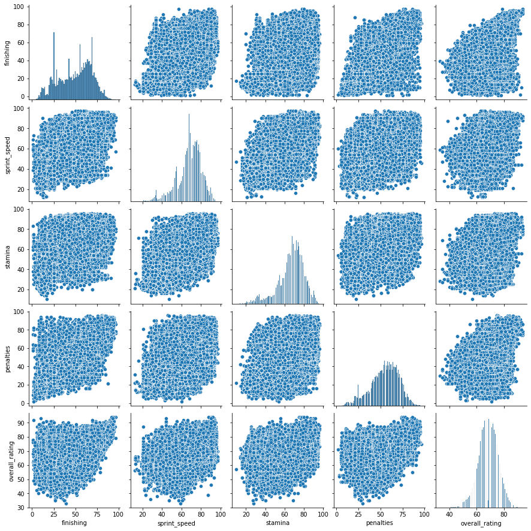

```python
# Load matplotlib and seaborn for visualization
import matplotlib.pyplot as plt
%matplotlib inline
import seaborn as sns

# Pairplots using seaborn
sns.pairplot(df_player_attributes.loc[:,['finishing','sprint_speed','stamina','penalties','overall_rating']]);
```

We can see **normal** distribution of these attributes in the histograms at the diagonal and from the scatter plots they all tend to have **positive** correlation with the `overall_rating`.

### Exploring Match Data

We can see from **Matches** data that there is no an easy way or single column that can inform us what is the final result of the match? Which team won the home or away team? Or if the match ended with a draw for both teams?

So, next we will create two columns for home and away teams to record in them the final result for each whether: `Win`, `Lose` or `Draw`. This will be done through comparison queries between columns `home_team_goal` and `away_team_goal` as follows.

```python
# Create "home_team_result" column to carry the final match result for the home team
df_match['home_team_result'] = ["Win" if match.home_team_goal > match.away_team_goal else "Lose" if match.home_team_goal < match.away_team_goal else "Draw" for match in df_match.itertuples()]
# Create "away_team_result" column to carry the final match result for the home team
df_match['away_team_result'] = ["Win" if match.away_team_goal > match.home_team_goal else "Lose" if match.away_team_goal < match.home_team_goal else "Draw" for match in df_match.itertuples()]

# Display Match dataframe with the new columns
df_match.head()
```

| id | season | stage | date | home_team_goal | away_team_goal | name_country | name_league | team_long_name_home | team_short_name_home | team_long_name_away | team_short_name_away | home_team_result | away_team_result |
| --- | --- | --- | --- | --- | --- | --- | --- | --- | --- | --- | --- | --- | --- |
| 1 | 2008/2009 | 1 | 2008-08-17 00:00:00 | 1 | 1 | Belgium | Belgium Jupiler League | KRC Genk | GEN | Beerschot AC | BAC | Draw | Draw |
| 2 | 2008/2009 | 1 | 2008-08-16 00:00:00 | 0 | 0 | Belgium | Belgium Jupiler League | SV Zulte-Waregem | ZUL | Sporting Lokeren | LOK | Draw | Draw |
| 3 | 2008/2009 | 1 | 2008-08-16 00:00:00 | 0 | 3 | Belgium | Belgium Jupiler League | KSV Cercle Brugge | CEB | RSC Anderlecht | AND | Lose | Win |
| 4 | 2008/2009 | 1 | 2008-08-17 00:00:00 | 5 | 0 | Belgium | Belgium Jupiler League | KAA Gent | GEN | RAEC Mons | MON | Win | Lose |
| 5 | 2008/2009 | 1 | 2008-08-16 00:00:00 | 1 | 3 | Belgium | Belgium Jupiler League | FCV Dender EH | DEN | Standard de Liège | STL | Lose | Win |

Now we can easily know the **final match result** for each of the **home** and **away** teams. Let's check the most winning teams when playing at home.

```python
# Query matches with "home_team_result" equal "Win" and check value counts for the "team_long_name_home"
home_team_win = df_match.query('home_team_result == "Win"').team_long_name_home.value_counts()

# Display the most winning home teams
home_team_win
```

```
FC Barcelona             131
Real Madrid CF           129
Celtic                   120
Manchester United        116
Manchester City          113
                        ...
AC Arles-Avignon           2
DSC Arminia Bielefeld      2
SV Darmstadt 98            2
Dunfermline Athletic       1
Córdoba CF                 1
Name: team_long_name_home, Length: 295, dtype: int64
```

Next we will visualize the bar plot for the top **20** teams which achieved winnings at home.

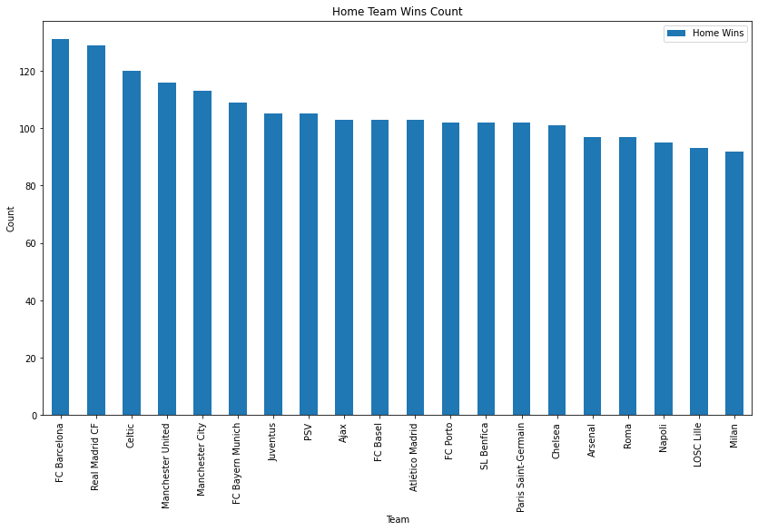

```python
# Par plot for to 20 home winning teams
home_team_win[:20].plot.bar(xlabel='Team', ylabel='Count', title='Home Team Wins Count', figsize=(14,8), label='Home Wins', legend=True);
```

Let's check the most winning teams when playing away.

```python
# Query matches with "away_team_result" equal "Win" and check value counts for the "team_long_name_away"
away_team_win = df_match.query('away_team_result == "Win"').team_long_name_away.value_counts()

# Display the most winning away teams
away_team_win
```

```
FC Barcelona              103
Real Madrid CF             99
Celtic                     98
FC Bayern Munich           84
Juventus                   84
                         ...
FC Dordrecht                1
FC Metz                     1
CD Tenerife                 1
Eintracht Braunschweig      1
Brescia                     1
Name: team_long_name_away, Length: 296, dtype: int64
```

Next we will visualize the bar plot for the top **20** teams which achieved winnings away.

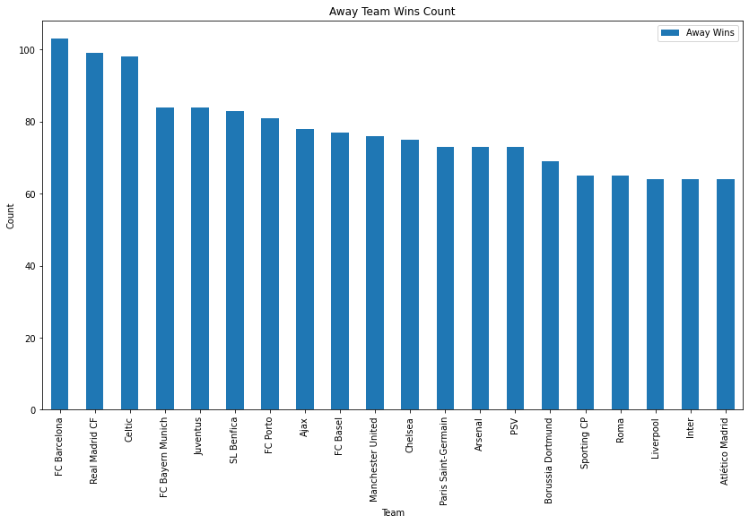

```python
# Par plot for to 20 away winning teams
away_team_win[:20].plot.bar(xlabel='Team', ylabel='Count', title='Away Team Wins Count', figsize=(14,8), label='Away Wins', legend=True)
```

We can see that teams like: `FC Barcelona`, `Real Madrid CF` and `Celtic` managed to preserve their winnings rank in the home and away matches. However, the attained less winnings when they are away. Other teams failed to keep their home winnings rank when playing away as `Manchester United` and `Manchester City`.

### Exploring Team Attributes Data

The Team's data has no single attribute to indicate how good a team is, as the `overall_rating` in the player's. So, we will try to create this indicator based on the "chance creation" attributes by **assuming** the following:

```
chanceCreationTotal = chanceCreationPassing + chanceCreationCrossing + chanceCreationShooting
```

```python
def chanceCreationList(team_attributes_dataframe):
    # Create empty list
    total_chance_creation_list = []
    # Loop over team attributes dataframe to calculate total chance creation for each team
    for team_attributes in team_attributes_dataframe.itertuples():
        # Caculate total chance creation by the summation formula
        total_chance_creation = team_attributes.chanceCreationPassing + team_attributes.chanceCreationCrossing \
                                + team_attributes.chanceCreationShooting
        # Append the calculate value to the list
        total_chance_creation_list.append(total_chance_creation)
    # Return the created full list
    return total_chance_creation_list
```

```python
# Create "chanceCreationTotal" column to carry a single indicator for team's performance
df_team_attributes['chanceCreationTotal'] = chanceCreationList(df_team_attributes)

# Display Team Attributes dataframe with the new column
df_team_attributes.head()
```

| id | date | buildUpPlaySpeed | buildUpPlaySpeedClass | buildUpPlayDribbling | buildUpPlayDribblingClass | buildUpPlayPassing | buildUpPlayPassingClass | buildUpPlayPositioningClass | chanceCreationPassing | chanceCreationPassingClass | ... | defencePressure | defencePressureClass | defenceAggression | defenceAggressionClass | defenceTeamWidth | defenceTeamWidthClass | defenceDefenderLineClass | team_long_name | team_short_name | chanceCreationTotal |
| --- | --- | --- | --- | --- | --- | --- | --- | --- | --- | --- | --- | --- | --- | --- | --- | --- | --- | --- | --- | --- | --- |
| 1 | 2010-02-22 00:00:00 | 60 | Balanced | 48.607362 | Little | 50 | Mixed | Organised | 60 | Normal | ... | 50 | Medium | 55 | Press | 45 | Normal | Cover | FC Aarau | AAR | 180 |
| 2 | 2014-09-19 00:00:00 | 52 | Balanced | 48.000000 | Normal | 56 | Mixed | Organised | 54 | Normal | ... | 47 | Medium | 44 | Press | 54 | Normal | Cover | FC Aarau | AAR | 181 |
| 3 | 2015-09-10 00:00:00 | 47 | Balanced | 41.000000 | Normal | 54 | Mixed | Organised | 54 | Normal | ... | 47 | Medium | 44 | Press | 54 | Normal | Cover | FC Aarau | AAR | 181 |
| 4 | 2010-02-22 00:00:00 | 70 | Fast | 48.607362 | Little | 70 | Long | Organised | 70 | Risky | ... | 60 | Medium | 70 | Double | 70 | Wide | Cover | Aberdeen | ABE | 210 |
| 5 | 2011-02-22 00:00:00 | 47 | Balanced | 48.607362 | Little | 52 | Mixed | Organised | 53 | Normal | ... | 47 | Medium | 47 | Press | 52 | Normal | Cover | Aberdeen | ABE | 153 |

5 rows × 25 columns

Let's check the correlation between the **original** chance creation attributes and the **total** one using heatmap representation.

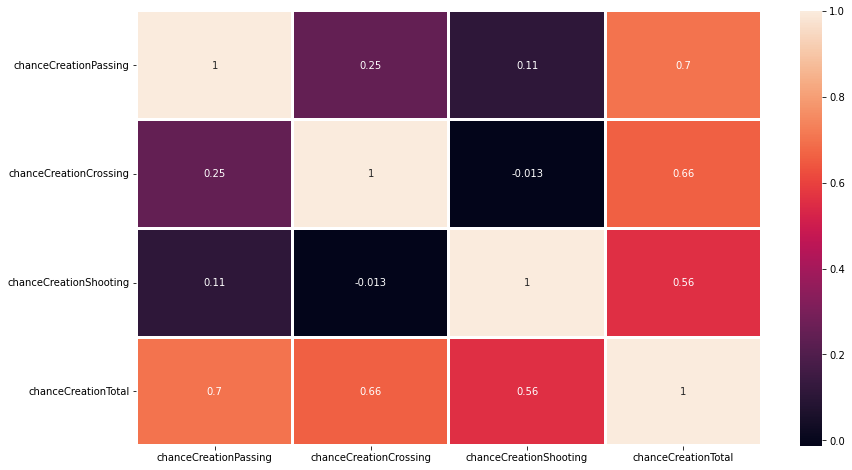

```python
# Select the chance creation only attributes columns from the Team Attributes dataframe
df_team_chanceCreation = df_team_attributes.loc[:,['chanceCreationPassing','chanceCreationCrossing', \
                                                   'chanceCreationShooting','chanceCreationTotal']]

# Plot heatmap for chance creation attributes with correlation values annotaion
plt.figure(figsize=(14,8))
sns.heatmap(df_team_chanceCreation.corr(),annot=True,linewidths=2)
```

As expected, all the original chance creation attributes have a **positive** correlation with new total chance creation. The `chanceCreationPassing` has the highest correlation of **0.7** with the total one.

## Conclusions

In this section we will draw the conclusions and answer all the posed questions at the beginning of this analysis process based on the previous exploratory data analysis. We will also demonstrate the limitations and all the assumptions made to reach these conclusions.

### Which players had the highest penalties' ratings of all time?

Let's query the data with the maximum penalties rating value and then get the unique players' names of the retrieved records.

```python
# Query Player Attributes dataframe with the maximum player's penalties rating value
max_penalties = df_player_attributes.penalties.max()
max_penalties_players = df_player_attributes.query('penalties == {}'.format(max_penalties))

# Display the unique names of players' having highest penalties rating
player_name = max_penalties_players.player_name.unique()[0]
print("{} is the player with max penalties rating of: {}".format(player_name,int(max_penalties)))
```

```
Rickie Lambert is the player with max penalties rating of: 96
```

We can see that a sole player `Rickie Lambert` is the only player who achieved the highest penalties rating of **96**.

**Assumptions:** since each player has variant penalties rating for different dates, so it is assumed that we are looking for best rating each player has ever reached across all time. Also, unique is used to eliminate redundant names as the same player may have scored the same penalties rating at different dates.

### What team's attributes lead to the most victories?

Let's join the previously explored home and away teams' wins to have a total wins number for each team. Since the home and away wins series are of **different** sizes, so we will make **outer** join to take there union and then fill the missing values with **zero** to be able to sum the two wins values after then.

```python
# Outer join the home and away teams' wins series into a single dataframe
combined_team_win = home_team_win.to_frame(name="home_win").join(away_team_win.to_frame(name="away_win"), how='outer')
# Fill the missing values from the union by zero
combined_team_win.fillna(0, inplace=True)
# Convert columns data types back to int after be chnaged to float on joining
combined_team_win = combined_team_win.astype(int)
# Display the combined dataframe
combined_team_win
```

|  | home_win | away_win |
| --- | --- | --- |
| 1. FC Kaiserslautern | 8 | 9 |
| 1. FC Köln | 32 | 28 |
| 1. FC Nürnberg | 30 | 19 |
| 1. FSV Mainz 05 | 55 | 33 |
| AC Ajaccio | 16 | 6 |
| ... | ... | ... |
| Xerez Club Deportivo | 6 | 2 |
| Zagłębie Lubin | 35 | 24 |
| Zawisza Bydgoszcz | 13 | 6 |
| Évian Thonon Gaillard FC | 29 | 16 |
| Śląsk Wrocław | 59 | 30 |

296 rows × 2 columns

Now let's create and extra column `total_win` to carry the summation of the `home_win` and `away_win`.

```python
# Create "total_win" to carry a single wins value for the team at home and away
combined_team_win['total_win'] = [team.home_win+team.away_win for team in combined_team_win.itertuples()]

# Display the dataframe with the new column
combined_team_win
```

|  | home_win | away_win | total_win |
| --- | --- | --- | --- |
| 1. FC Kaiserslautern | 8 | 9 | 17 |
| 1. FC Köln | 32 | 28 | 60 |
| 1. FC Nürnberg | 30 | 19 | 49 |
| 1. FSV Mainz 05 | 55 | 33 | 88 |
| AC Ajaccio | 16 | 6 | 22 |
| ... | ... | ... | ... |
| Xerez Club Deportivo | 6 | 2 | 8 |
| Zagłębie Lubin | 35 | 24 | 59 |
| Zawisza Bydgoszcz | 13 | 6 | 19 |
| Évian Thonon Gaillard FC | 29 | 16 | 45 |
| Śląsk Wrocław | 59 | 30 | 89 |

296 rows × 3 columns

Now we can sort descendingly and list the total wins of each team to get the teams with the most victories.

```python
# Get total wins from the combined_team_win dataframe and sort them descendingly
team_total_win = combined_team_win.total_win.sort_values(ascending = False)

# Display list of first five teams with the most victories.
team_total_win.head()
```

```
FC Barcelona         234
Real Madrid CF       228
Celtic               218
FC Bayern Munich     193
Manchester United    192
Name: total_win, dtype: int64
```

Since `FC Barcelona` is the team with hightest total victories, we can analyze its attributes to learn who they reached this huge number of wins!

```python
# Get the name of the most winning team
most_winning_team_name = team_total_win.index[0]
# Print the name of the most winning team
print("The most winning team is: {}".format(most_winning_team_name))
```

```
The most winning team is: FC Barcelona
```

```python
# Get the attributes of the most winning team from Team Attributes dataframe
most_winning_attributes = df_team_attributes[df_team_attributes['team_long_name'] == most_winning_team_name]

# Display the most winning attributes
most_winning_attributes
```

| id | date | buildUpPlaySpeed | buildUpPlaySpeedClass | buildUpPlayDribbling | buildUpPlayDribblingClass | buildUpPlayPassing | buildUpPlayPassingClass | buildUpPlayPositioningClass | chanceCreationPassing | chanceCreationPassingClass | ... | defencePressure | defencePressureClass | defenceAggression | defenceAggressionClass | defenceTeamWidth | defenceTeamWidthClass | defenceDefenderLineClass | team_long_name | team_short_name | chanceCreationTotal |
| --- | --- | --- | --- | --- | --- | --- | --- | --- | --- | --- | --- | --- | --- | --- | --- | --- | --- | --- | --- | --- | --- |
| 119 | 2010-02-22 00:00:00 | 42 | Balanced | 48.607362 | Little | 30 | Short | Free Form | 65 | Normal | ... | 70 | High | 30 | Contain | 70 | Wide | Offside Trap | FC Barcelona | BAR | 175 |
| 120 | 2011-02-22 00:00:00 | 43 | Balanced | 48.607362 | Little | 34 | Mixed | Free Form | 59 | Normal | ... | 67 | High | 43 | Press | 68 | Wide | Cover | FC Barcelona | BAR | 152 |
| 121 | 2012-02-22 00:00:00 | 24 | Slow | 48.607362 | Little | 25 | Short | Free Form | 37 | Normal | ... | 66 | Medium | 63 | Press | 66 | Normal | Cover | FC Barcelona | BAR | 115 |
| 122 | 2013-09-20 00:00:00 | 35 | Balanced | 48.607362 | Little | 32 | Short | Free Form | 37 | Normal | ... | 61 | Medium | 63 | Press | 65 | Normal | Cover | FC Barcelona | BAR | 103 |
| 123 | 2014-09-19 00:00:00 | 35 | Balanced | 35.000000 | Normal | 32 | Short | Free Form | 37 | Normal | ... | 61 | Medium | 63 | Press | 65 | Normal | Cover | FC Barcelona | BAR | 103 |
| 124 | 2015-09-10 00:00:00 | 36 | Balanced | 35.000000 | Normal | 51 | Mixed | Free Form | 36 | Normal | ... | 61 | Medium | 65 | Press | 65 | Normal | Cover | FC Barcelona | BAR | 141 |

6 rows × 25 columns

Since `FC Barcelona` has different attributes' values for different dates. So, we can take the **mode** of each attribute to get the team's attributes that led to the most victories.

```python
# Get the mode of the winning attributes starting after "date"
most_winning_attributes.iloc[:, 1:].mode()
```

|  | buildUpPlaySpeed | buildUpPlaySpeedClass | buildUpPlayDribbling | buildUpPlayDribblingClass | buildUpPlayPassing | buildUpPlayPassingClass | buildUpPlayPositioningClass | chanceCreationPassing | chanceCreationPassingClass | chanceCreationCrossing | ... | defencePressure | defencePressureClass | defenceAggression | defenceAggressionClass | defenceTeamWidth | defenceTeamWidthClass | defenceDefenderLineClass | team_long_name | team_short_name | chanceCreationTotal |
| --- | --- | --- | --- | --- | --- | --- | --- | --- | --- | --- | --- | --- | --- | --- | --- | --- | --- | --- | --- | --- | --- |
| 0 | 35 | Balanced | 48.607362 | Little | 32 | Short | Free Form | 37 | Normal | 31 | ... | 61 | Medium | 63 | Press | 65 | Normal | Cover | FC Barcelona | BAR | 103 |

1 rows × 24 columns

### What teams improved the most over the time period?

We can calculate the team's improvement as the **difference** between the latest `chanceCreationTotal` and the oldest one by date. So that the **higher** the difference is the **better** the improvement!

```python
def calculateTeamsImprovement(threshold=None):
    # Create empty list to hold teams' improvement values
    chance_creation_improvement_list = []
    # Create empty list to hold improved teams above the threshold
    most_improved_teams = []
    # Loop over teams' groups to calculate teams' improvement values
    for name, group in df_team_attributes.groupby('team_long_name'):
        # Calculate improvement by substracting oldest "total chance creation" from the lastest one by date
        chance_creation_improvement_list.append(group['chanceCreationTotal'].iloc[-1] - group['chanceCreationTotal'].iloc[0])
        # Add the team group to the improved teams list if the improvement is greater than the threshold
        if threshold != None and chance_creation_improvement_list[-1] >= threshold:
            most_improved_teams.append((name, group))
    # Sort the improvement values descendingly
    chance_creation_improvement_list.sort(reverse=True)
    # Convert list to numpy array to easily apply optimized vectorization methods
    chance_creation_improvement_list = np.array(chance_creation_improvement_list)
    # Return the created lists
    return chance_creation_improvement_list, most_improved_teams
```

First, let's check all the improvement values to help us decide a **threshold** for the teams' to be considered as the most improved over time.

```python
# Calculate all teams improvement values
teams_improvement_values, _ = calculateTeamsImprovement()
# Print the teams improvement values
print(teams_improvement_values)
```

```
[  76   71   68   60   54   54   51   49   45   43   43   41   39   38
   35   34   33   32   31   29   29   28   27   25   25   25   23   23
   23   23   22   21   21   21   21   21   21   20   20   19   19   19
   19   19   19   18   18   18   18   17   17   17   16   16   16   15
   15   15   14   14   14   12   12   12   12   11   11   11   11   10
   10   10   10    9    9    8    8    8    8    7    7    7    7    6
    6    6    6    6    5    5    5    4    4    4    4    4    3    3
    3    3    2    2    2    1    1    1    1    1    0    0    0    0
    0    0    0    0    0    0    0    0    0    0    0    0    0    0
    0    0    0    0    0   -1   -1   -1   -1   -2   -2   -2   -2   -2
   -2   -3   -3   -3   -3   -3   -5   -5   -5   -5   -6   -6   -7   -7
   -7   -7   -7   -7   -7   -8   -8   -9   -9   -9  -10  -11  -11  -12
  -12  -13  -13  -14  -14  -14  -15  -15  -15  -15  -16  -16  -16  -16
  -16  -17  -17  -18  -18  -18  -18  -18  -19  -19  -20  -20  -20  -20
  -21  -21  -21  -21  -21  -22  -23  -23  -24  -24  -24  -25  -25  -26
  -26  -26  -27  -28  -28  -28  -28  -28  -28  -30  -30  -30  -31  -32
  -32  -32  -32  -33  -33  -33  -34  -34  -34  -34  -34  -35  -35  -36
  -36  -36  -37  -37  -38  -39  -39  -39  -39  -40  -40  -41  -41  -41
  -41  -43  -44  -45  -46  -46  -46  -46  -47  -47  -48  -48  -52  -55
  -56  -56  -56  -57  -59  -59  -59  -60  -61  -64  -66  -69  -72  -77
  -79  -85  -89  -97 -115]
```

From the above list we can pick **35** as our threshold value for the most improved teams over time. In the next code cell we will get and display the names of the most improved teams over time.

```python
# Set threshold value
improvement_threshold = 35
# Get the teams that improved above or equal to this threshold
_, most_improved_teams = calculateTeamsImprovement(improvement_threshold)

# Displaye the names of the improved teams
for name, _ in most_improved_teams:
    print(name)
```

```
AC Arles-Avignon
AZ
Cagliari
Empoli
FC Energie Cottbus
FC Sochaux-Montbéliard
FC Thun
Lazio
Lech Poznań
Napoli
Reggio Calabria
Sassuolo
Siena
Stade Brestois 29
Udinese
```

### Results (Our data suggest the following)

1. To attain most victories your need to have the following attributes:
   - Balanced buid-up speed
   - Little build-up play dribbling
   - Short build-up play passing
   - Free form build-up play positioning
   - Normal chance creation passing
   - Little chance creation crossing
   - Normal chance creation shooting
   - Free form chance creation positioning
   - Medium defence pressure
   - Press defence aggression
   - Normal defence team width
   - Cover defence defender line
2. Teams with most victories are not the most improving over time.
3. Most of the teams could preserve a close away winning rank to their home one.
4. The max penalties rating is only achieved by a single player.

### Limitations (There are a couple of limitations with our data)

1. Some of player's and team's data were missing and we needed to fill numerical values by mean and categorical by mode.
2. Teams improvement values' calculation is based on the summation of the chance creation values which may not be the best indicator of improvement.
3. Highest penalties ratings were calculated as the absolute maximum regardless of the time period they were achieved at.
4. Teams and players attributes are not sampled at the same dates or even with the same number of weeks.

## Communication

In this last section we will communicate our results through aiding visualizations

### Players with the highest penalties' ratings of all time

Next we will the display the top **20** players with the highest penalties' ratings of all time.

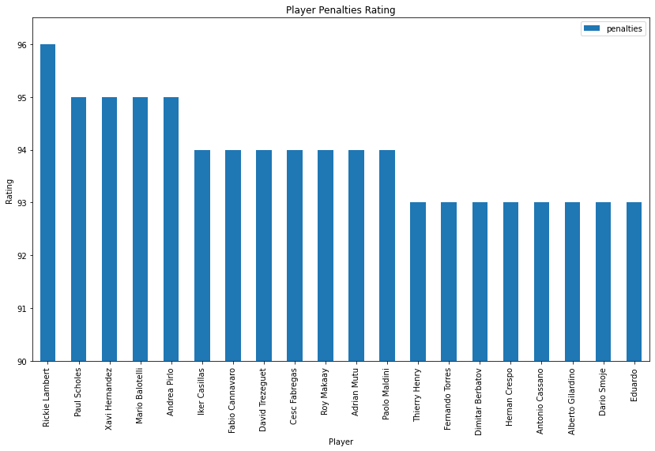

```python
# Select only "player_name" and "penalties" from Player Attributes dataframe then group by player's name and select the max penalties rating
df_player_penalties = df_player_attributes.loc[:,['player_name','penalties']].groupby('player_name').max()

# Sort the penalties rating descendingly then bar plot the rating of the top 20 players
df_player_penalties.sort_values('penalties', ascending=False)[:20].plot.bar(xlabel='Player', ylabel='Rating', title='Player Penalties Rating', ylim=(90, 96.5), figsize=(14,8));
```

### Team's with the most victories

Next we will the display the top **50** teams with the most home and away victories.

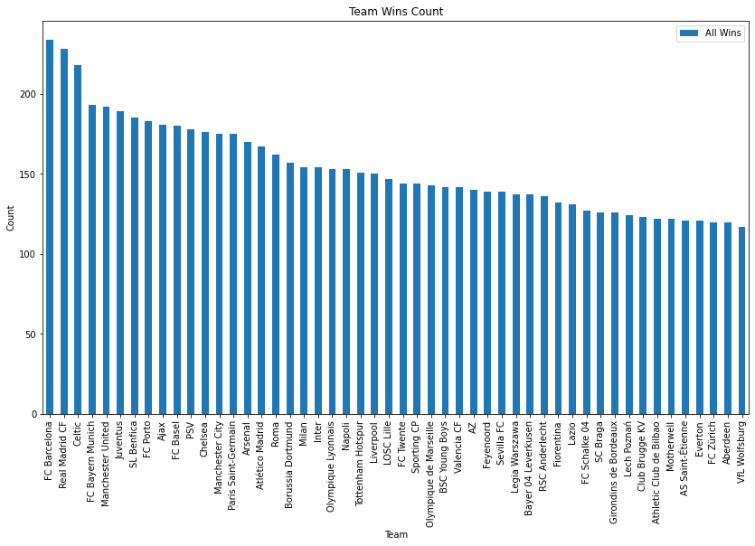

```python
team_total_win[:50].plot.bar(xlabel='Team', ylabel='Count', title='Team Wins Count', label='All Wins', legend=True, figsize=(14,8));
```

### Teams improved the most over the time period

Next we will display the improvement line curves for the **15** most improved teams over the time.

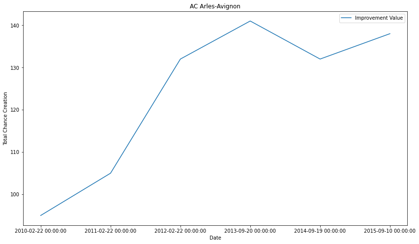

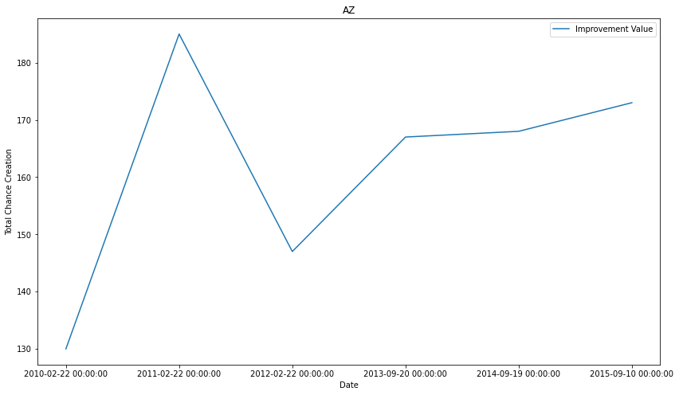

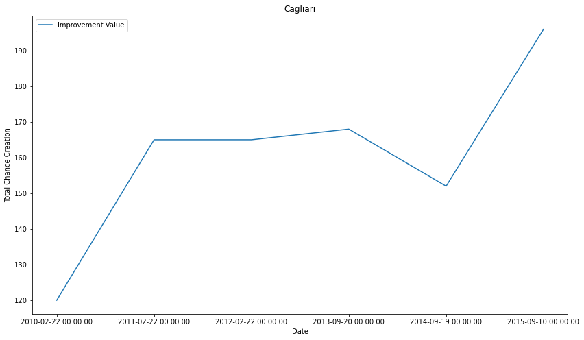

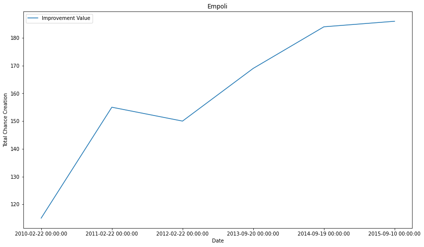

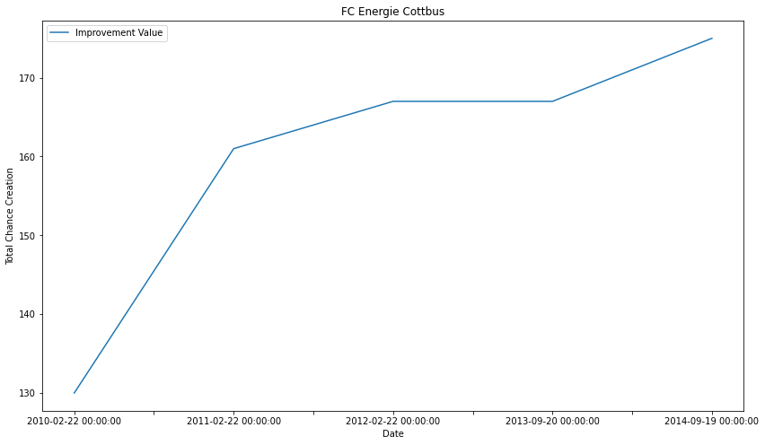

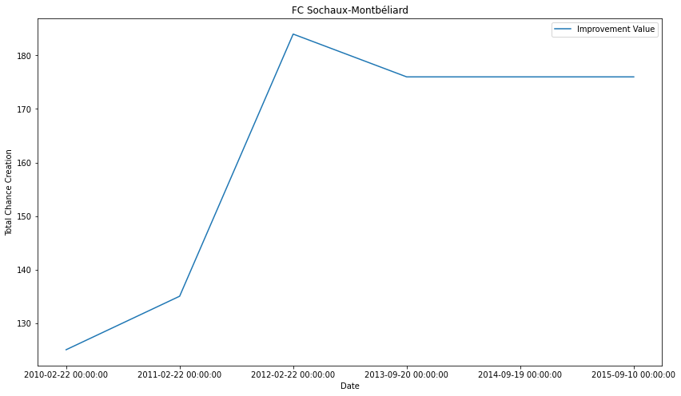

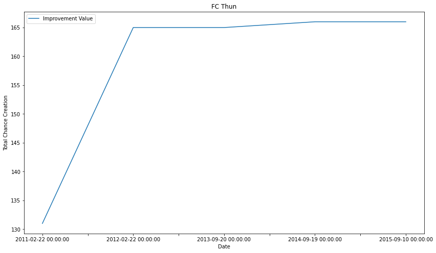

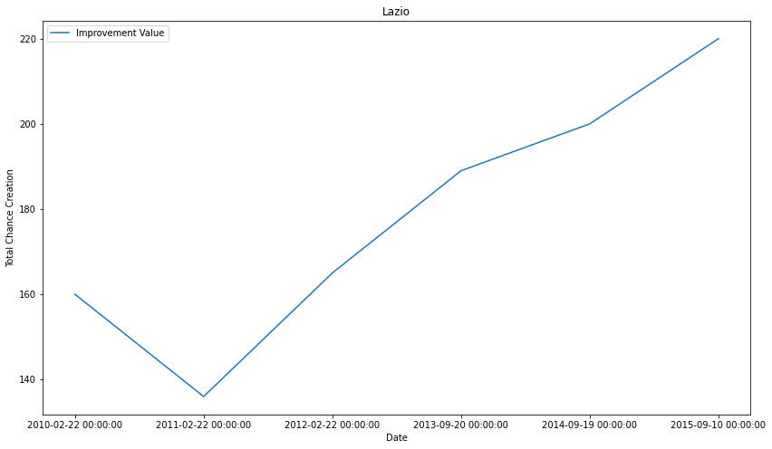

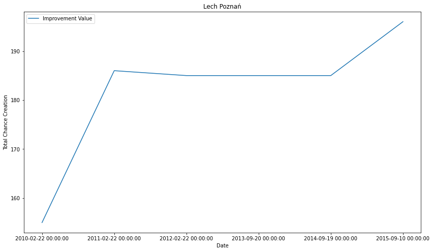

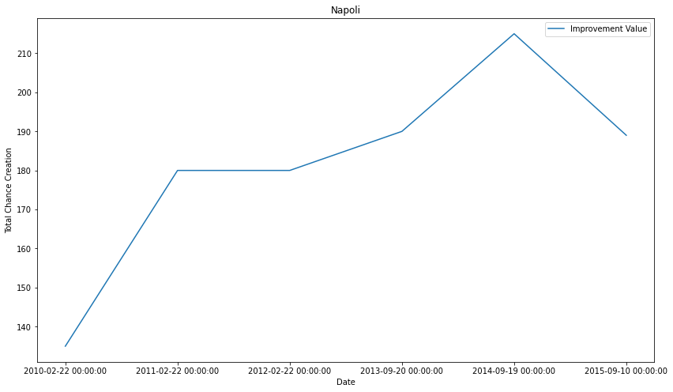

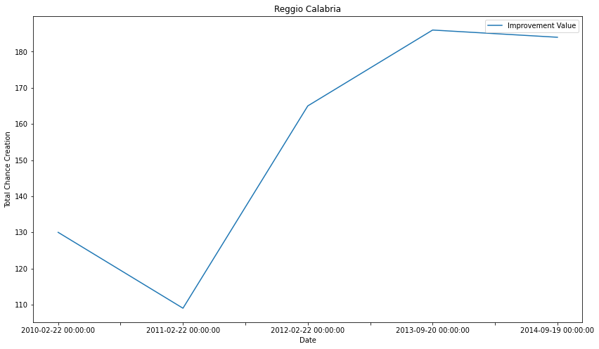

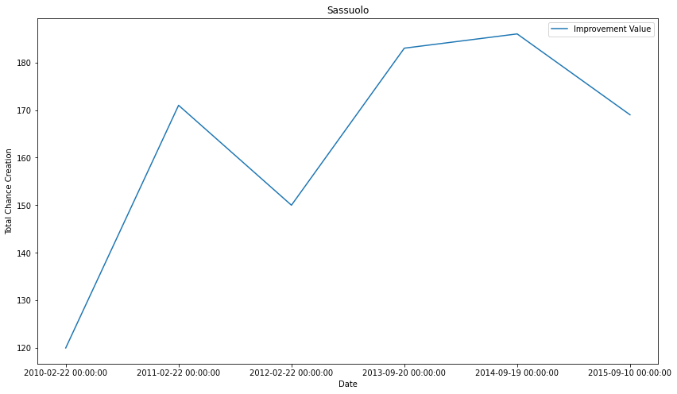

[3 more figures not shown]

```python
for name, group in most_improved_teams:
    group.plot.line(x='date', y='chanceCreationTotal', xlabel='Date', ylabel='Total Chance Creation', title=name, label='Improvement Value', figsize=(14,8));
```